# FACTOR ANALYSIS dan SVM Tugas Besar FSD

Fakhri Ilham (18523060) & Muhammad Farhan (18523099)

**dataset yang digunakan adalah FIFA 2018 Man of the Match**

dataset dapat diunduh melalui link berikut: https://www.kaggle.com/mathan/fifa-2018-match-statistics

**Karakteristik dataset :**

1. tersusun dari 128 baris dan 27 fitur
2. Merupakan dataset dengan tipe data string dan numerik
3. Memiliki data yang kosong atau `NA` (sehingga akan dilakukan preprocessing untuk mengganti `NA` menjadi 0)

## **LANGKAH 1 (FA):**

- Melakukan import dataset dengan membaca csv yang berlokasi dalam satu folder proyek
- mereduksi fitur dengan feature selection `c(4:20, 22)`
- melakukan replacement nilai kolom NA menjadi 0 dengan fungsi `is.na()`

```r
#install.packages('psych')
library(psych)
myData <- read.csv("FIFA 2018 Statistics.csv")
fifa_results <- myData[,c(4:20, 22)]

fifa_results$X1st.Goal[is.na(fifa_results$X1st.Goal)] <- 0

head(fifa_results)
```

```
##   Goal.Scored Ball.Possession.. Attempts On.Target Off.Target Blocked Corners
## 1           5                40       13         7          3       3       6
## 2           0                60        6         0          3       3       2
## 3           0                43        8         3          3       2       0
## 4           1                57       14         4          6       4       5
## 5           0                64       13         3          6       4       5
## 6           1                36        8         2          5       1       2
##   Offsides Free.Kicks Saves Pass.Accuracy.. Passes Distance.Covered..Kms.
## 1        3         11     0              78    306                    118
## 2        1         25     2              86    511                    105
## 3        1          7     3              78    395                    112
## 4        1         13     3              86    589                    111
## 5        0         14     2              86    433                    101
## 6        0         22     2              86    194                    100
##   Fouls.Committed Yellow.Card Yellow...Red Red X1st.Goal
## 1              22           0            0   0        12
## 2              10           0            0   0         0
## 3              12           2            0   0         0
## 4               6           0            0   0        89
## 5              22           1            0   0         0
## 6              14           3            0   0        90
```

### **LANGKAH 2 (FA):**

Cari tahu variabel mana yang dapat dipertimbangkan untuk FA:

Untuk mengetahui variable mana yang paling relevan kita dapat menggunakan Tes Kaiser-Meyer-Olkin (KMO). Fungsi `KMO()` dari package `psych` akan memeriksa apakah suatu variabel cocok untuk Factor Analysis

- Membuat matriks korelasi dengan fungsi `cor(fifa_results)`
- Menggunakan fungsi `KMO()` untuk memeriksa kecocokan variable

```r
df_corr <- cor(fifa_results)
KMO(df_corr)
```

```
## Kaiser-Meyer-Olkin factor adequacy
## Call: KMO(r = df_corr)
## Overall MSA =  0.56
## MSA for each item =
##            Goal.Scored      Ball.Possession..               Attempts
##                   0.62                   0.74                   0.52
##              On.Target             Off.Target                Blocked
##                   0.37                   0.35                   0.43
##                Corners               Offsides             Free.Kicks
##                   0.93                   0.49                   0.53
##                  Saves        Pass.Accuracy..                 Passes
##                   0.78                   0.83                   0.70
## Distance.Covered..Kms.        Fouls.Committed            Yellow.Card
##                   0.22                   0.68                   0.60
##           Yellow...Red                    Red              X1st.Goal
##                   0.49                   0.52                   0.45
```

**Catatan :**

- MSA (ukuran kecukupan sampling) adalah ukuran untuk mengecualikan variabel.
- Jika MSA <0,5 variabel akan tereliminasi.
- Variabel dengan MSA> 0.6 akan cocok,
- variabel dengan MSA> 0.8 akan sangat cocok untuk Factor Analysis

### **LANGKAH 3 (FA):**

Mengeliminasi variable yang tidak dibutuhkan dengan memilih fitur `c(1:3, 7, 9:12, 14:15, 17)`

```r
df1_fifaRes <- fifa_results[,c(1:3, 7, 9:12, 14:15, 17)]
head(df1_fifaRes)
```

```
##   Goal.Scored Ball.Possession.. Attempts Corners Free.Kicks Saves
## 1           5                40       13       6         11     0
## 2           0                60        6       2         25     2
## 3           0                43        8       0          7     3
## 4           1                57       14       5         13     3
## 5           0                64       13       5         14     2
## 6           1                36        8       2         22     2
##   Pass.Accuracy.. Passes Fouls.Committed Yellow.Card Red
## 1              78    306              22           0   0
## 2              86    511              10           0   0
## 3              78    395              12           2   0
## 4              86    589               6           0   0
## 5              86    433              22           1   0
## 6              86    194              14           3   0
```

### **LANGKAH 4 (FA):**

- Membuat matriks korelasi dengan variable yang sudah dipilih dari `df1_fifaRes`
- Memberi warna untuk mempermudah visualisasi
- Tambahkan koefisien korelasi dengan code `addCoef.col = "black"`
- Memberi warna label dan rotasinya dengan `tl.col="black", tl.srt=45`
- sembunyikan koefisien korelasi pada diagonal utama `diag=FALSE`
- Memvisualisasikan korelasi matriks kedalam bentuk tabel `round(df1_corr, 2)`

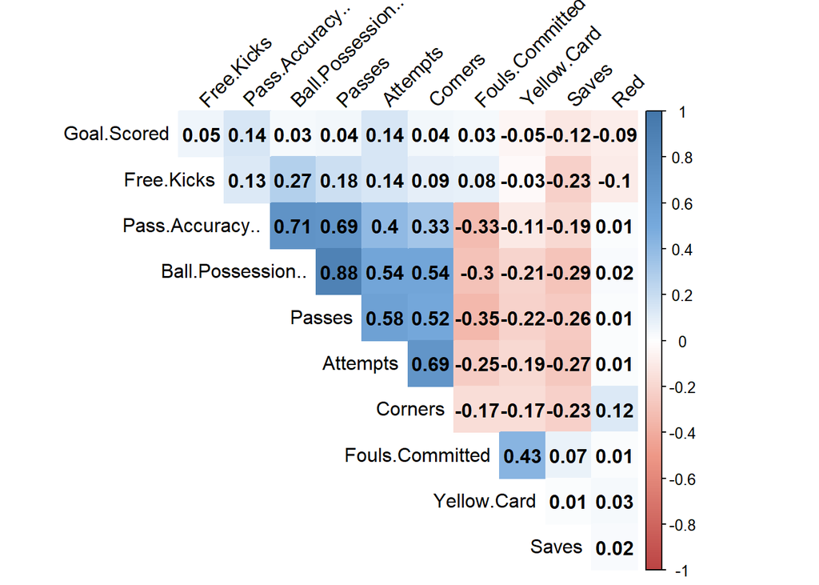

```r
library(corrplot)
df1_corr <- cor(df1_fifaRes)
col <- colorRampPalette(c("#BB4444", "#EE9988", "#FFFFFF", "#77AADD", "#4477AA"))
corrplot(round(df1_corr, 2), method="color", col=col(200),
         type="upper", order="hclust",
         addCoef.col = "black",
         tl.col="black", tl.srt=45,
         diag=FALSE)
```

```r
round(df1_corr, 2)
```

```
##                   Goal.Scored Ball.Possession.. Attempts Corners Free.Kicks
## Goal.Scored              1.00              0.03     0.14    0.04       0.05
## Ball.Possession..        0.03              1.00     0.54    0.54       0.27
## Attempts                 0.14              0.54     1.00    0.69       0.14
## Corners                  0.04              0.54     0.69    1.00       0.09
## Free.Kicks               0.05              0.27     0.14    0.09       1.00
## Saves                   -0.12             -0.29    -0.27   -0.23      -0.23
## Pass.Accuracy..          0.14              0.71     0.40    0.33       0.13
## Passes                   0.04              0.88     0.58    0.52       0.18
## Fouls.Committed          0.03             -0.30    -0.25   -0.17       0.08
## Yellow.Card             -0.05             -0.21    -0.19   -0.17      -0.03
## Red                     -0.09              0.02     0.01    0.12      -0.10
##                   Saves Pass.Accuracy.. Passes Fouls.Committed Yellow.Card
## Goal.Scored       -0.12            0.14   0.04            0.03       -0.05
## Ball.Possession.. -0.29            0.71   0.88           -0.30       -0.21
## Attempts          -0.27            0.40   0.58           -0.25       -0.19
## Corners           -0.23            0.33   0.52           -0.17       -0.17
## Free.Kicks        -0.23            0.13   0.18            0.08       -0.03
## Saves              1.00           -0.19  -0.26            0.07        0.01
## Pass.Accuracy..   -0.19            1.00   0.69           -0.33       -0.11
## Passes            -0.26            0.69   1.00           -0.35       -0.22
## Fouls.Committed    0.07           -0.33  -0.35            1.00        0.43
## Yellow.Card        0.01           -0.11  -0.22            0.43        1.00
## Red                0.02            0.01   0.01            0.01        0.03
##                     Red
## Goal.Scored       -0.09
## Ball.Possession..  0.02
## Attempts           0.01
## Corners            0.12
## Free.Kicks        -0.10
## Saves              0.02
## Pass.Accuracy..    0.01
## Passes             0.01
## Fouls.Committed    0.01
## Yellow.Card        0.03
## Red                1.00
```

Setelah melakukan visualisasi matriks correlation, kita tahu berapa banyak faktor yang perlu digunakan dari grafik yang diberikan di atas (yaitu 4 faktor).

pengambilan 4 faktor ini didasari oleh sebaran warna yang dapat terlihat secara kasat mata

FA akan dilakukan dengan fungsi `fa()` dari package `psych` dengan *mem-passing parameter* : matriks korelasi, jumlah faktor, dan rotasi.

### **LANGKAH 5 (FA):**

- Menggunakan library `GPArotation` dan `psych`
- Meng-assign `nfactors` menjadi 4 berdasarkan rekomendasi dari matriks korelasi dari langkah sebelumnya

```r
library('GPArotation')
library(psych)
nfactors <- 4
nvars <- dim(df1_corr)[1]
factors <- fa(r = df1_corr, nfactors = nfactors, rotate = "Varimax")
factors
```

```
## Factor Analysis using method =  minres
## Call: fa(r = df1_corr, nfactors = nfactors, rotate = "Varimax")
## Standardized loadings (pattern matrix) based upon correlation matrix
##                     MR1   MR3   MR2   MR4    h2    u2 com
## Goal.Scored        0.05  0.06  0.01  0.25 0.067 0.933 1.2
## Ball.Possession..  0.93  0.25 -0.10  0.06 0.932 0.068 1.2
## Attempts           0.41  0.62 -0.14  0.19 0.614 0.386 2.1
## Corners            0.33  0.89 -0.05 -0.03 0.897 0.103 1.3
## Free.Kicks         0.24  0.02  0.12  0.38 0.214 0.786 1.9
## Saves             -0.25 -0.18 -0.01 -0.34 0.207 0.793 2.4
## Pass.Accuracy..    0.72  0.10 -0.17  0.03 0.563 0.437 1.2
## Passes             0.86  0.28 -0.18  0.02 0.856 0.144 1.3
## Fouls.Committed   -0.20 -0.06  0.98  0.01 0.996 0.004 1.1
## Yellow.Card       -0.11 -0.12  0.41 -0.06 0.200 0.800 1.4
## Red                0.01  0.12  0.03 -0.26 0.083 0.917 1.4
##
##                        MR1  MR3  MR2  MR4
## SS loadings           2.58 1.39 1.23 0.43
## Proportion Var        0.23 0.13 0.11 0.04
## Cumulative Var        0.23 0.36 0.47 0.51
## Proportion Explained  0.46 0.25 0.22 0.08
## Cumulative Proportion 0.46 0.70 0.92 1.00
##
## Mean item complexity =  1.5
## Test of the hypothesis that 4 factors are sufficient.
##
## The degrees of freedom for the null model are  55  and the objective function was  4.21
## The degrees of freedom for the model are 17  and the objective function was  0.17
##
## The root mean square of the residuals (RMSR) is  0.03
## The df corrected root mean square of the residuals is  0.05
##
## Fit based upon off diagonal values = 0.99
## Measures of factor score adequacy
##                                                    MR1  MR3  MR2   MR4
## Correlation of (regression) scores with factors   0.96 0.93 1.00  0.60
## Multiple R square of scores with factors          0.93 0.87 1.00  0.36
## Minimum correlation of possible factor scores     0.86 0.75 0.99 -0.28
```

### **LANGKAH 6 (FA):**

Melakukan plotting untuk mendapatkan visualisasi FA

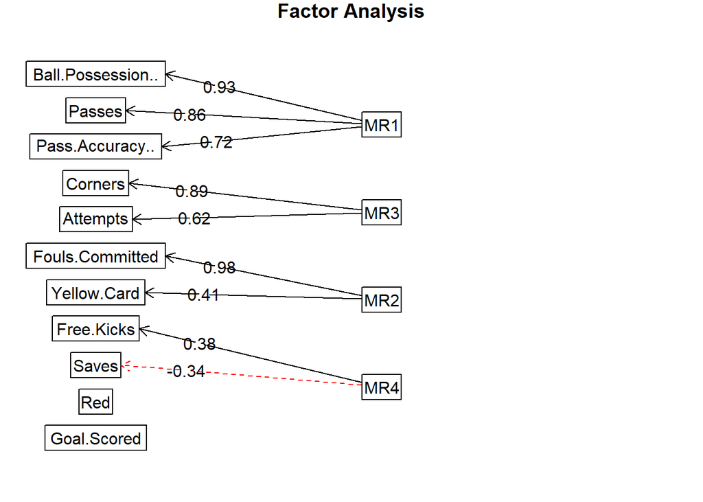

```r
load <- factors$loadings[,1:4]
fa.diagram(factors, digits = 2)
```

**Temuan dari plotting :**

Setelah melakukan plotting kita mendapatkan bahwa :

- **Faktor 1** : Kontrol Permainan (‘Ball Possesion’, ‘Passes’, dan ‘Pass Accuracy’)
- **Faktor 2** : Teknik Penyerangan (‘Corners’ dan ‘Attempts’)
- **Faktor 3** : Peraturan permainan (‘Fouls Committed’, dan ‘Yellow Card’)
- **Faktor 4** : Lain-lain ( ‘Free Kicks’ ,dan ‘Saves’) dan memiliki nilai negatif

### **LANGKAH 7 (FA):**

[figure not shown]

```r
plot(load, type="n")
text(load,labels=names(factors),cex=.7)
```

Terlihat dalam plot, sebaran **factor loading** memiliki nilai yang sangat variatif

### **LANGKAH 8 (FA):**

Terdapa cara lain untuk dapat menentukan jumlah faktor, kita dapat menggunakan bantuan **scree plot** apabila kita tidak memiliki dasar ilmiah untuk menentukan jumlah faktor.

```r
library('psy')
```

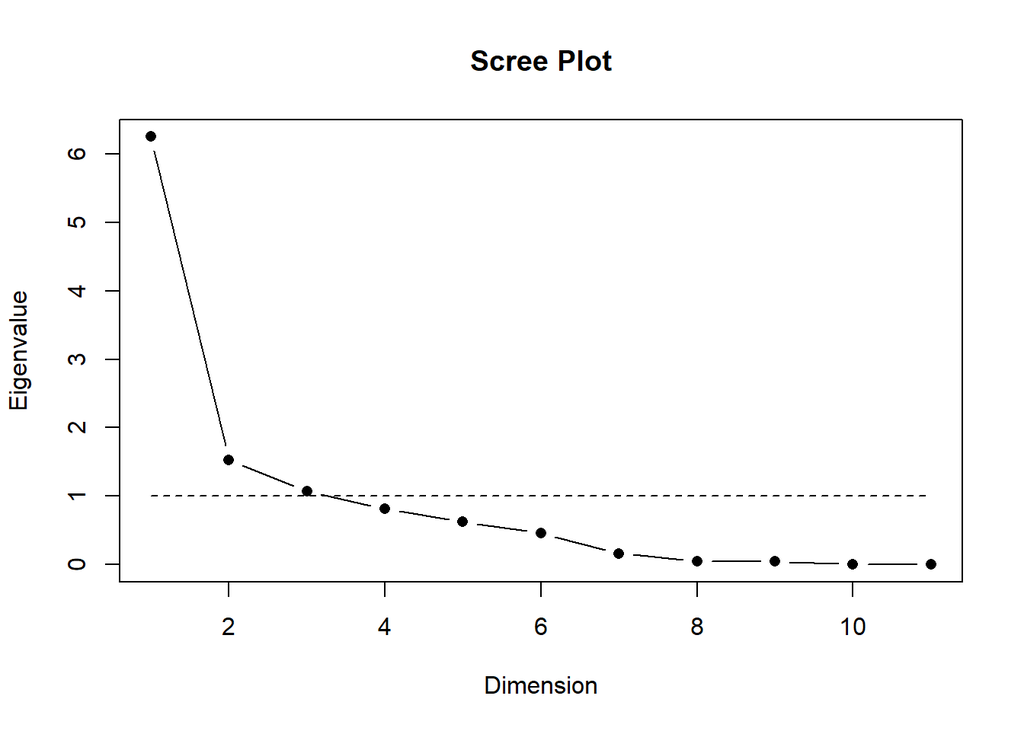

```r
scree.plot(df1_corr)
```

**Temuan dari Screeplot :**

- jumlah faktor yang disarankan adalah 3 faktor
- hal ini juga menjadi alasan mengapa plotting FA sebelumnya (dengan metode **Correlation Matrix** menunjukkan bahwa faktor ke-4 sangat sedikit menunjukkan hubungannya dengan fitur-fitur terkait, bahkan ada yang bernilai negatif.

### **LANGKAH 9 (SVM) :**

Membuat variable R baru dengan nama `filteredFifa`, dengan memasukkan beberapa fitur dari dataset berbekal pengetahuan yang didapatkan dari FA

Pengetahuan yand didapatkan adalah memilih 4 fitur dengan nilai terbesar untuk dijadikan sebagai **data training** dan **data testing** dalam SVM

```r
library(psych)
filteredFifa <- myData[,c(5, 10, 17, 12)]

head(filteredFifa)
```

```
##   Ball.Possession.. Corners Fouls.Committed Free.Kicks
## 1                40       6              22         11
## 2                60       2              10         25
## 3                43       0              12          7
## 4                57       5               6         13
## 5                64       5              22         14
## 6                36       2              14         22
```

### **LANGKAH 10 (SVM Fitur Ball.Possesion) :**

#### **Melakukan training dan testing terhadap fitur *Ball.Possesion* yang merupakan perwakilan dari Factor pertama**

1. Menggunakan library `caret` yang merupakan package untuk *Classification and Regression Training*

```r
library(caret)
```

2. Melakukan data splitting dengan komposisi 70% training dan 30% testing dengan method `createDataPartition()`
3. Mengassign hasil split ke dalam variable `trainingBallPossesion` dan `testingBallPossesion`
4. Mengecek jumlah dimensi dari data dengan method `dim()`

```r
intrainBallPossesion <- createDataPartition(y=filteredFifa$Ball.Possession.., p=0.7, list=FALSE)
trainingBallPossesion <- filteredFifa[intrainBallPossesion,]
testingBallPossesion <- filteredFifa[-intrainBallPossesion,]

dim(trainingBallPossesion)
```

```
## [1] 91  4
```

```r
dim(testingBallPossesion)
```

```
## [1] 37  4
```

5. Melakukan `set` terhadap `seed`

```r
set.seed(132)
```

```r
trainingBallPossesion[["Ball.Possession.."]] = factor(trainingBallPossesion[["Ball.Possession.."]])
```

```r
trainControl_BallPossesion <- trainControl(method = "repeatedcv", number=2, repeats = 3)
```

8. Membuat model SVM dari data `trainingBallPossesion` menggunakan fungsi `train()` dari library `caret`

```r
svmLinear_BallPossesion <- train(Ball.Possession.. ~., data = trainingBallPossesion, method = "svmLinear",
                        trControl = trainControl_BallPossesion,
                        preProcess = c("center", "scale"),
                        tuneLength = 10)
```

9. Akurasi dari tiap-tiap fold dari proses *training* sebelumnya dapat dilihat dengan

```r
svmLinear_BallPossesion$resample
```

```
##     Accuracy       Kappa   Resample
## 1 0.04761905  0.01118305 Fold1.Rep1
## 2 0.06122449  0.03921569 Fold2.Rep1
## 3 0.00000000 -0.02880658 Fold1.Rep2
## 4 0.07317073  0.04884005 Fold2.Rep2
## 5 0.04255319  0.01627907 Fold1.Rep3
## 6 0.04545455  0.01334757 Fold2.Rep3
```

**Catatan dan temuan :**

- dari proses pembangunan model ternyata diperoleh bahwa akurasi dari model sangatlah buruk
- sehingga dapat disimpulkan bahwa model SVM tidak cocok untuk dataset ini
- Mari kita lanjutkan dengan dengan menghitung prediksi dari model untuk mendukung argumen poin 2
9. Melakukan prediksi terhadap model SVM setelah membangun model dengan fungsi `predict()`

```r
prediction_BallPossesion <- predict(svmLinear_BallPossesion, newdata =testingBallPossesion)
show(prediction_BallPossesion)
```

```
##  [1] 57 47 61 52 48 52 41 48 61 52 47 43 61 44 47 47 52 48 61 43 48 61 44 39 57
## [26] 43 57 59 61 40 61 52 48 47 48 59 41
## 40 Levels: 25 28 29 30 32 34 35 36 37 38 39 40 41 42 43 44 45 46 47 48 ... 75
```

**Catatan dan temuan :**

```r
confusionMatrix(svmLinear_BallPossesion)
```

```
## Cross-Validated (2 fold, repeated 3 times) Confusion Matrix
##
## (entries are percentual average cell counts across resamples)
##
##           Reference
## Prediction  25  28  29  30  32  34  35  36  37  38  39  40  41  42  43  44  45
##         25 0.0 0.0 0.0 0.0 0.0 0.0 0.0 0.0 0.0 0.0 0.0 0.4 0.0 0.0 0.0 0.0 0.0
##         28 0.0 0.0 0.0 0.0 0.0 0.0 0.0 0.0 0.0 0.0 0.0 0.0 0.0 0.0 0.0 0.0 0.0
##         29 0.0 0.0 0.0 0.0 0.0 0.4 0.0 0.0 0.0 0.0 0.4 0.0 0.4 0.0 0.7 0.0 0.0
##         30 0.0 0.0 0.0 0.0 0.0 0.0 0.0 0.0 0.0 0.0 0.0 0.0 0.0 0.0 0.0 0.0 0.0
##         32 0.0 0.0 0.4 0.4 0.0 0.4 0.4 0.0 0.4 0.0 0.0 0.4 0.4 0.0 0.7 0.0 0.0
##         34 0.0 0.0 0.0 0.0 0.0 0.0 0.0 0.0 0.0 0.0 0.0 0.0 0.0 0.0 0.0 0.0 0.0
##         35 0.4 0.4 0.0 0.0 0.4 0.0 0.0 0.0 0.0 0.0 1.1 0.4 0.7 0.0 0.7 0.0 0.0
##         36 0.0 0.0 0.4 0.0 0.0 0.0 0.4 0.4 0.0 0.0 0.0 0.0 0.4 0.4 0.0 0.0 0.0
##         37 0.0 0.0 0.0 0.0 0.4 0.0 0.0 0.0 0.0 0.0 0.4 0.0 0.0 0.0 0.4 0.0 0.0
```

[output cut: 117 more lines]

**Catatan dan temuan :**

- dapat kita simpulkan bahwa model SVM tidak disarankan untuk dataset ini karena akurasi memang terbukti sangat rendah dilihat dari nilai `Accuracy (average)` diatas
- Mari kita buat model SVM untuk kasus fitur lain

### **LANGKAH 11 (SVM Fitur Corners) :**

#### **Melakukan training dan testing terhadap fitur *Corners* yang merupakan perwakilan dari Factor kedua**

1. Menggunakan library `caret` yang merupakan package untuk *Classification and Regression Training*

```r
library(caret)
```

2. Melakukan data splitting dengan komposisi 70% training dan 30% testing dengan method `createDataPartition()`
3. Mengassign hasil split ke dalam variable `trainingCorners` dan `testingCorners`
4. Mengecek jumlah dimensi dari data dengan method `dim()`

```r
intrainCorners <- createDataPartition(y=filteredFifa$Corners, p=0.7, list=FALSE)
trainingCorners <- filteredFifa[intrainCorners,]
testingCorners <- filteredFifa[-intrainCorners,]

dim(trainingCorners)
```

```
## [1] 92  4
```

```r
dim(testingCorners)
```

```
## [1] 36  4
```

5. Melakukan `set` terhadap `seed`

```r
set.seed(132)
```

```r
trainingCorners[["Corners"]] = factor(trainingCorners[["Corners"]])
```

```r
trainControl_Corners <- trainControl(method = "repeatedcv", number=2, repeats = 3)
```

8. Membuat model SVM dari data `trainingCorners` menggunakan fungsi `train()` dari library `caret`

```r
svmLinear_Corners <- train(Corners ~., data = trainingCorners, method = "svmLinear",
                        trControl = trainControl_Corners,
                        preProcess = c("center", "scale"),
                        tuneLength = 10)
```

9. Akurasi dari tiap-tiap fold dari proses *training* sebelumnya dapat dilihat dengan

```r
svmLinear_Corners$resample
```

```
##    Accuracy        Kappa   Resample
## 1 0.1521739  0.003333333 Fold1.Rep1
## 2 0.1521739 -0.003917180 Fold2.Rep1
## 3 0.1521739 -0.010704225 Fold1.Rep2
## 4 0.1086957 -0.046034387 Fold2.Rep2
## 5 0.1521739 -0.010704225 Fold1.Rep3
## 6 0.1739130  0.024553571 Fold2.Rep3
```

**Catatan dan temuan :**

- dari proses pembangunan model ternyata diperoleh bahwa akurasi dari model dengan fitur Corners masih terbilang rendah
- sehingga dapat disimpulkan bahwa model SVM masih belum direkomendasikan untuk dataset ini
- Mari kita lanjutkan dengan dengan menghitung prediksi dari model untuk mendukung argumen poin 2
9. Melakukan prediksi terhadap model SVM setelah membangun model dengan fungsi `predict()`

```r
prediction_Corners <- predict(svmLinear_Corners, newdata =testingCorners)
show(prediction_Corners)
```

```
##  [1] 2 3 3 1 2 2 2 2 5 2 5 3 5 5 5 5 5 2 3 5 2 2 5 3 5 5 2 5 1 7 5 3 5 5 5 5
## Levels: 1 2 3 4 5 6 7 8 9 10 11
```

```r
show(testingCorners$Corners)
```

```
##  [1]  0  2  4  2  4  1  2  5  7  3  6  5  3  3 10  8  5  3 10  9  5  5  5  0  6
## [26]  7  0  6  5  4  8  3  3  8  8  5
```

**Catatan dan temuan :**

- dapat kita lihat bahwa nilai dari prediksi sebagian besar meleset dari data sebenarnya
- Mari kita lanjutkan dengan melihat *confussion matrix* model SVM dengan fitur Corners ini

```r
confusionMatrix(svmLinear_Corners)
```

```
## Cross-Validated (2 fold, repeated 3 times) Confusion Matrix
##
## (entries are percentual average cell counts across resamples)
##
##           Reference
## Prediction   1   2   3   4   5   6   7   8   9  10  11
##         1  0.0 0.7 0.0 0.7 0.7 0.0 0.7 0.0 0.0 0.0 0.0
##         2  4.0 5.1 7.2 2.9 2.5 1.1 2.9 0.7 0.0 0.0 0.0
##         3  0.7 4.0 1.1 1.8 2.9 0.7 1.1 0.0 0.0 0.0 0.0
##         4  0.7 0.0 0.4 0.4 2.9 1.1 0.7 0.0 0.0 0.0 0.0
##         5  0.0 3.3 3.3 3.3 5.8 6.2 6.2 1.4 2.2 1.8 0.4
##         6  0.7 1.1 0.0 0.0 1.1 0.7 0.7 0.7 0.0 0.0 0.0
##         7  0.4 1.1 1.1 1.8 3.6 1.1 1.8 0.4 0.0 1.4 0.7
##         8  0.0 0.0 0.0 0.0 0.0 0.0 0.0 0.0 0.0 0.0 0.0
##         9  0.0 0.0 0.0 0.0 0.0 0.0 0.0 0.0 0.0 0.0 0.0
##         10 0.0 0.0 0.0 0.0 0.0 0.0 0.0 0.0 0.0 0.0 0.0
##         11 0.0 0.0 0.0 0.0 0.0 0.0 0.0 0.0 0.0 0.0 0.0
##
##  Accuracy (average) : 0.1486
```

**Catatan dan temuan :**

- dapat kita simpulkan bahwa model SVM tidak disarankan untuk dataset ini karena akurasi memang masih terbukti sangat rendah dilihat dari nilai `Accuracy (average)` diatas
- Sehingga dapat disimpulkan SVM juga tidak cocok untuk fitur lain dari dataset ini